# Part II - (Ford Go Bike)

## by Lilian Some

## Investigation Overview

In this investigation, I examined how various variables affect bike trips across the bay area and how customer characterisitics( age, gender) affect biking outcomes.

## Dataset Overview

The data has information 183412 rides made in a bike-sharing system in the San Francisco Bay area. The outstanding features include duration in secs, customer type, gender etc

## (Distribution of Popular bike times)

Observation:

The peak time for usage is moning hours ( 8.00 hrs & 9.00 hours) and evening (17.00 hours & 18.00 hrs). This can be to rush hours where people leave for work and come back later in the evening The lowest usage time is between 0.00hrs to 5.00hrs . This could mean that these are night hours hence low human activity

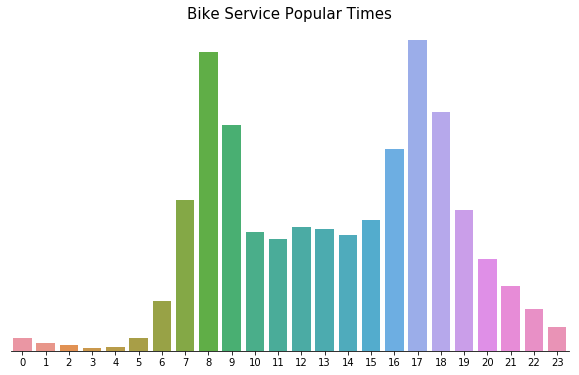

## Distribution between age and trip duration

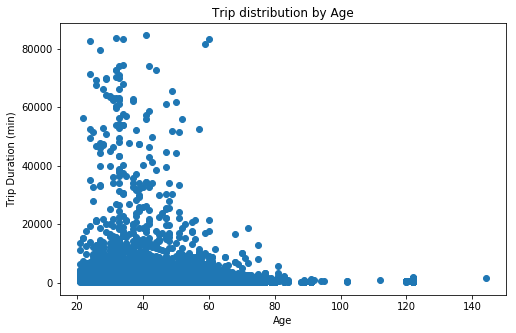

## What is the Relationship between trip duration and Gender?

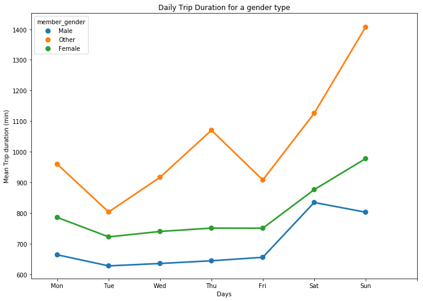